# UI LabView

03 05 2021

### Пользовательский интерфейс программы для контроля и управления положением зеркала в двух плоскостях.

#### Константин Осипов (проект РНФ: апрель - март 2020)

1. Перед запуском программы должно быть включено питание (220 В) на контроллеры двигателей и датчика положение.
2. Запуск программы Mirror осуществляется стандартно из рабочей папки Mirror.
3. По умолчанию программа запускается автоматически, и начинается опрос датчиков положения с контроллера ИТМ (это необходимо пр оверить по меняющимся данным на индикаторах).
4. Параметры, устанавливаемые по умолчанию при запуске программы для контроллеров обоих двигателей:
- Ток 500 мА
- Микрошаг 16
- Ускорение, начальная и конечная скорость = 0
1. С помощью переменных Speed и Steps с передней панели программы устанавливаются соответствующие параметры для обоих контроллеров
2. Большая круглая кнопка СТОП прекращает любое движение обоих двигателей, и обесточивает обмотки. (желательно ее нажимать принудительно, после того как вы закончите двигать зеркало).
3. Остановка программы и выход из нее осуществляется по квадратной кнопке стоп внизу справа.

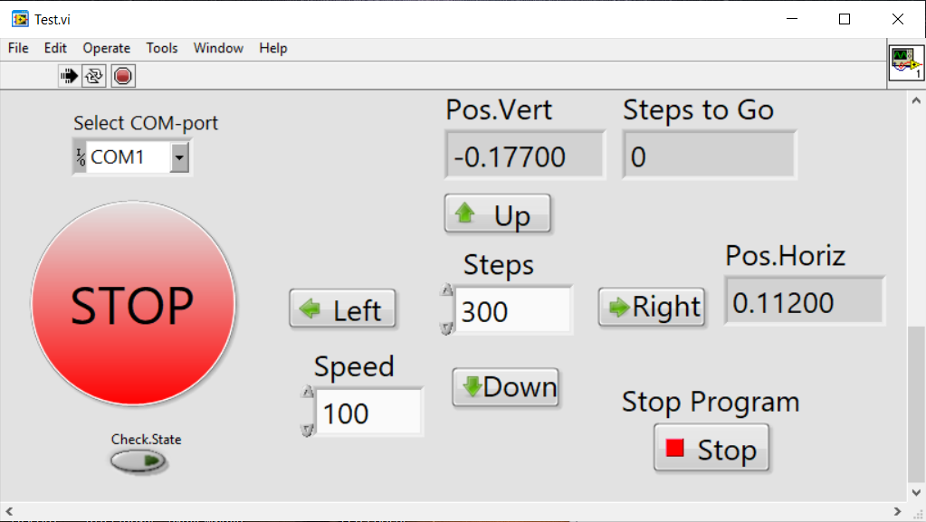

Рисунок 1. Скриншот основного окна программы.

#### Порядок действий включения системы управления зеркалом после длительного перерыва в работе, какого-либо сбоя, отсутствия питания.

В этом случае может произойти сброс контроллера к исходным (заводским) установкам. Может сбиться скорость обмена данными контроллера с компьютером. Абсолютный датчик положения ИТМ и контроллеры двигателей подключены к компьютеру по одной шине ModBus. Датчики ИТМ могут работать на скорости обмена шины до 38400 бит/с. А заводские настройки контроллеров двигателей - это скорость 57600 бит/с. Но сделано так, что я исходно специально вручную в программе Modbus Terminal понижаю скорость обмена контроллеров двигателей до 38400 , и тогда все эти контроллеры работают совместно на одной шине. НО если, контроллеры сбросятся к заводским настройкам, то все собъется, и сделанная программа работать не будет.

Итак, чтобы проверить это:

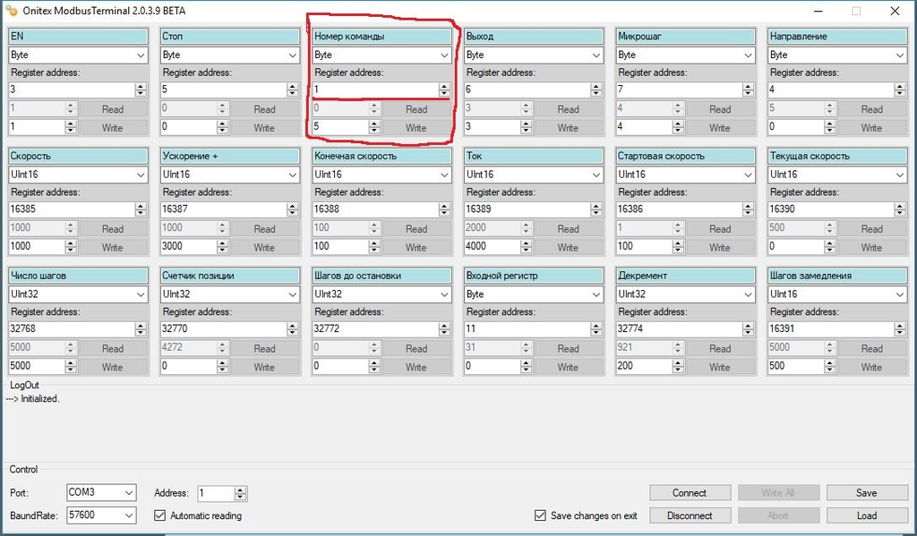